# spotify_finaltutorial

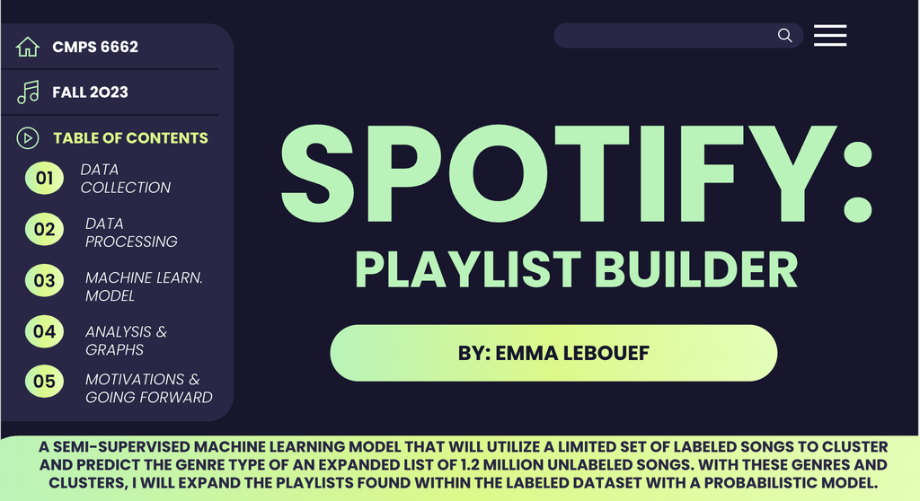

[GITHUB WEBSITE](https://emmalebouef.github.io/)

**FINAL TUTORIAL -- BY EMMA LEBOUEF**

## **Establishing a Viable Workspace**

```python
# mounting my google drive
from google.colab import drive
drive.mount('/content/drive')
# changing the directory to my folder designated for this project
%cd /content/drive/My Drive/TU/SEMESTERS/f2023/datascience
```

```
[Errno 2] No such file or directory: '/content/drive/My Drive/TU/SEMESTERS/f2023/datascience'
/content
```

```python
# importing important packages I will need
import pandas as pd
import numpy as np
import seaborn as sns
import matplotlib.pyplot as plt
from sklearn.decomposition import PCA
from sklearn.cluster import KMeans
from sklearn.preprocessing import StandardScaler
from sklearn.linear_model import LogisticRegression
import random
```

```python
import warnings
warnings.filterwarnings("ignore", message="X does not have valid feature names, but PCA was fitted with feature names")
```

## **MOTIVATIONS & GOALS**

> DATA SCIENCE MOTIVATION:
> - Build a Spotify Recommendation System for playlist expansion utilizing data science tools such as semi-supervised machine learning, logistic classification, and probabalistic outcome limiting.
> - Recommendation engines are rapidly expanding in many B2B and B2C companies, as a future data scientist, I wanted to expand my familiarity with building recommendations systems as much of my current portfolio is centered around supervised machine learning projects.
> - An introductory article to the benefits of semi-supervised machine learning can be found [here](https://medium.com/@ohermans1/the-benefits-of-semi-supervised-learning-enhance-your-machine-learning-projects-today-85da0f6c6c5a)
> - A brief summary of recommendation engines can be found [here](https://towardsdatascience.com/recommendation-systems-explained-a42fc60591ed)
> - A project outline of how to build a Kmeans clustering algorithm with limited labeled outcomes can be found [here](https://towardsdatascience.com/semi-supervised-learning-with-k-means-clustering-6e837158c54a)
> - Class notes from Tulane's CMPS 6240 that I utilized to shape my code can be found [here](https://colab.research.google.com/drive/1PyGLJrOdkJwvG5qYMB5CJy2DIVWd0cnU#scrollTo=iIc1wfXM7Ug7)
> - Other Playlist / Music Recommendation Tutorials can be found [here](https://towardsdatascience.com/how-to-build-an-amazing-music-recommendation-system-4cce2719a572), and [here](https://bitsandmusic.com/post/playlist-recommender-system/), and also [here](https://towardsdatascience.com/part-iii-building-a-song-recommendation-system-with-spotify-cf76b52705e7)!

## **DATA COLLECTION**

*For this project, all my data came from publically available Kaggle files.*

### **DATASET ONE: 1.2 MILLION UNLABELED TRACKS**

*The [dataset](https://www.kaggle.com/datasets/rodolfofigueroa/spotify-12m-songs) below contains information on over 1.2 million unique tracks from Spotify. For every track a series of features are recorded. These features can range from tempo to the amount of accosticness. I will utilize this dataset to expand the options available in playlist generator later on in this project.*

```python
track_features = pd.read_csv('//content/drive/MyDrive/TU/SEMESTERS/f2023/data science/tracks_features.csv')
# the ids were alphanumeric and meaningless, will create numeric ids later
track_features = track_features.drop(columns = {'id', 'album_id', 'artist_ids'})
# the artists column is a lists of artists, taking the primary artist only
track_features[['primary_artist']] = track_features['artists'].str.split("'", expand=True)[[1]]
# track number and disc number are irrelevant to the analyses we will be performing
track_features = track_features.drop(columns = {'artists', 'track_number', 'disc_number'})
track_features.head()
```

|  | name | album | explicit | danceability | energy | key | loudness | mode | speechiness | acousticness | instrumentalness | liveness | valence | tempo | duration_ms | time_signature | year | release_date | primary_artist |
| --- | --- | --- | --- | --- | --- | --- | --- | --- | --- | --- | --- | --- | --- | --- | --- | --- | --- | --- | --- |
| 0 | Testify | The Battle Of Los Angeles | False | 0.470 | 0.978 | 7 | -5.399 | 1 | 0.0727 | 0.02610 | 0.000011 | 0.3560 | 0.503 | 117.906 | 210133 | 4.0 | 1999 | 1999-11-02 | Rage Against The Machine |
| 1 | Guerrilla Radio | The Battle Of Los Angeles | True | 0.599 | 0.957 | 11 | -5.764 | 1 | 0.1880 | 0.01290 | 0.000071 | 0.1550 | 0.489 | 103.680 | 206200 | 4.0 | 1999 | 1999-11-02 | Rage Against The Machine |
| 2 | Calm Like a Bomb | The Battle Of Los Angeles | False | 0.315 | 0.970 | 7 | -5.424 | 1 | 0.4830 | 0.02340 | 0.000002 | 0.1220 | 0.370 | 149.749 | 298893 | 4.0 | 1999 | 1999-11-02 | Rage Against The Machine |
| 3 | Mic Check | The Battle Of Los Angeles | True | 0.440 | 0.967 | 11 | -5.830 | 0 | 0.2370 | 0.16300 | 0.000004 | 0.1210 | 0.574 | 96.752 | 213640 | 4.0 | 1999 | 1999-11-02 | Rage Against The Machine |
| 4 | Sleep Now In the Fire | The Battle Of Los Angeles | False | 0.426 | 0.929 | 2 | -6.729 | 1 | 0.0701 | 0.00162 | 0.105000 | 0.0789 | 0.539 | 127.059 | 205600 | 4.0 | 1999 | 1999-11-02 | Rage Against The Machine |

*All dtypes are as expected. Artist, album, and name are all strings. The remaining variables are either integers, booleans, or float values. I manually converted release date to datetime*

```python
track_features['release_date'] = pd.to_datetime(track_features['release_date'], format='yyyy-mm-dd', errors='coerce')
track_features.dtypes
```

```
name                        object
album                       object
explicit                      bool
danceability               float64
energy                     float64
key                          int64
loudness                   float64
mode                         int64
speechiness                float64
acousticness               float64
instrumentalness           float64
liveness                   float64
valence                    float64
tempo                      float64
duration_ms                  int64
time_signature             float64
year                         int64
release_date        datetime64[ns]
primary_artist              object
dtype: object
```

### **DATASET TWO: MULTI GENRE MUSIC WITH PLAYLIST TITLES**

*The [dataset](https://www.kaggle.com/datasets/siropo/spotify-multigenre-playlists-data/) below is very similar to previous, it contains quantitative information on a unique song in Spotify. However, unlike the other dataset, there is also information about the genres, subgenres, and playlists Spotify has grouped these songs under. There are over 20k tracks represented. I will utilize this dataset when building the labeling model later on in this project*

```python
# IMPORTING EACH OF THE DATASETS FROM MY GOOGLE DRIVE AND ADDING A CATEGORY BASED ON THE DATAFRAME THEY ARE IN
hip_hop = pd.read_csv('//content/drive/MyDrive/TU/SEMESTERS/f2023/data science/hiphop_music_data.csv')
hip_hop['main_cat'] = 'hip hop'

indie = pd.read_csv('//content/drive/MyDrive/TU/SEMESTERS/f2023/data science/indie_alt_music_data.csv')
indie['main_cat'] = 'indie'

metal = pd.read_csv('//content/drive/MyDrive/TU/SEMESTERS/f2023/data science/metal_music_data.csv')
metal['main_cat'] = 'metal'

pop = pd.read_csv('//content/drive/MyDrive/TU/SEMESTERS/f2023/data science/pop_music_data.csv')
pop['main_cat'] = 'pop'

rock = pd.read_csv('//content/drive/MyDrive/TU/SEMESTERS/f2023/data science/rock_music_data.csv')
rock['main_cat'] = 'rock'

## CONCAT EACH FRAME INTO ONE LARGE FRAME
multi_genre = pd.concat([hip_hop, indie, metal, pop, rock], ignore_index= True)
# EACH SONG HAS A LIST OF GENRES DESIGNATED BY SPOTIFY, I HAVE SELECTED THREE OF THESE SUBGENRES TO INCLUDE IN MY DATA
multi_genre[['subgenre1', 'subgenre2', 'subgenre3']] = multi_genre['Genres'].str.split("'", expand=True)[[1, 3, 5]]
# DROPPING UNNECESSARY COLUMNS
multi_genre = multi_genre.drop(columns = {
       'id', 'uri', 'track_href', 'analysis_url',
       'time_signature', 'Genres'})
multi_genre.head()
```

|  | Artist Name | Track Name | Popularity | Playlist | danceability | energy | key | loudness | mode | speechiness | acousticness | instrumentalness | liveness | valence | tempo | duration_ms | main_cat | subgenre1 | subgenre2 | subgenre3 |
| --- | --- | --- | --- | --- | --- | --- | --- | --- | --- | --- | --- | --- | --- | --- | --- | --- | --- | --- | --- | --- |
| 0 | 21 Savage | Spiral | 63 | No Cap | 0.814 | 0.659 | 2 | -4.475 | 1 | 0.0829 | 0.00155 | 0.025100 | 0.568 | 0.130 | 88.506 | 171527 | hip hop | atl hip hop | rap | trap |
| 1 | VIC MENSA | SHELTER ft Wyclef Jean, ft Chance The Rapper | 55 | Mellow Bars | 0.664 | 0.660 | 0 | -5.284 | 1 | 0.2910 | 0.18100 | 0.000002 | 0.190 | 0.470 | 90.106 | 261467 | hip hop | chicago rap | conscious hip hop | hip hop |
| 2 | Pooh Shiesty | Welcome To The Riches (feat. Lil Baby) | 0 | No Cap | 0.842 | 0.400 | 11 | -11.308 | 0 | 0.4860 | 0.04570 | 0.000000 | 0.172 | 0.205 | 130.018 | 192052 | hip hop | memphis hip hop | rap | southern hip hop |
| 3 | Athletic Progression | Stepney Tale | 37 | Jazz Rap | 0.632 | 0.800 | 5 | -7.227 | 0 | 0.2340 | 0.54700 | 0.000000 | 0.147 | 0.496 | 92.757 | 209833 | hip hop | aarhus indie | danish modern jazz | jazz rap |
| 4 | Ghetts | Fire and Brimstone | 46 | Grime Shutdown | 0.846 | 0.511 | 1 | -8.116 | 1 | 0.2630 | 0.03750 | 0.000005 | 0.147 | 0.346 | 136.964 | 190773 | hip hop | grime | uk alternative hip hop | uk hip hop |

*The appropriate dtypes for the multi-genre dataframe are displayed below*

```python
multi_genre.dtypes
```

```
Artist Name          object
Track Name           object
Popularity            int64
Playlist             object
danceability        float64
energy              float64
key                   int64
loudness            float64
mode                  int64
speechiness         float64
acousticness        float64
instrumentalness    float64
liveness            float64
valence             float64
tempo               float64
duration_ms           int64
main_cat             object
subgenre1            object
subgenre2            object
subgenre3            object
dtype: object
```

## **DATA PROCESSING**

*My data processing was limited to merging the two dataframes, cleaning column names, and removing columns that were not shared between the two datasets.*

```python
# CHANGING THE NAMES OF ARTIST AND TRACK IN MULTIGENRE FOR EASE OF MERGING
multi_genre= multi_genre.rename(columns = {"Artist Name" : "primary_artist", "Track Name" : "name"})
combo = pd.concat([multi_genre, track_features], ignore_index= True)
# DROPPING COLUMNS NOT SHARED BETWEEEN THE TWO FRAMES
combo = combo.drop(columns = {'album','explicit',
       'time_signature', 'year', 'release_date', 'Popularity'})
# THERE IS BOUND TO BE OVERLAP BETWEEN THE TWO DATAFRAMES, DROPPING DUPLICATES BASED ON ARTIST NAME, SONG NAME PAIRINGS
combo = combo.drop_duplicates(subset = ['primary_artist', 'name'], keep = 'first')
combo.head()
```

|  | primary_artist | name | Playlist | danceability | energy | key | loudness | mode | speechiness | acousticness | instrumentalness | liveness | valence | tempo | duration_ms | main_cat | subgenre1 | subgenre2 | subgenre3 |
| --- | --- | --- | --- | --- | --- | --- | --- | --- | --- | --- | --- | --- | --- | --- | --- | --- | --- | --- | --- |
| 0 | 21 Savage | Spiral | No Cap | 0.814 | 0.659 | 2 | -4.475 | 1 | 0.0829 | 0.00155 | 0.025100 | 0.568 | 0.130 | 88.506 | 171527 | hip hop | atl hip hop | rap | trap |
| 1 | VIC MENSA | SHELTER ft Wyclef Jean, ft Chance The Rapper | Mellow Bars | 0.664 | 0.660 | 0 | -5.284 | 1 | 0.2910 | 0.18100 | 0.000002 | 0.190 | 0.470 | 90.106 | 261467 | hip hop | chicago rap | conscious hip hop | hip hop |
| 2 | Pooh Shiesty | Welcome To The Riches (feat. Lil Baby) | No Cap | 0.842 | 0.400 | 11 | -11.308 | 0 | 0.4860 | 0.04570 | 0.000000 | 0.172 | 0.205 | 130.018 | 192052 | hip hop | memphis hip hop | rap | southern hip hop |
| 3 | Athletic Progression | Stepney Tale | Jazz Rap | 0.632 | 0.800 | 5 | -7.227 | 0 | 0.2340 | 0.54700 | 0.000000 | 0.147 | 0.496 | 92.757 | 209833 | hip hop | aarhus indie | danish modern jazz | jazz rap |
| 4 | Ghetts | Fire and Brimstone | Grime Shutdown | 0.846 | 0.511 | 1 | -8.116 | 1 | 0.2630 | 0.03750 | 0.000005 | 0.147 | 0.346 | 136.964 | 190773 | hip hop | grime | uk alternative hip hop | uk hip hop |

```python
print(f"There are {combo.main_cat.value_counts().sum()} labeled rows remaining in our dataframe and a total of {len(combo)} unique songs to build our model with")
```

```
There are 16503 labeled rows remaining in our dataframe and a total of 1140107 unique songs to build our model with
```

```python
# HOW MUCH INFORMATION DO WE HAVE FROM EACH COLUMN
combo.info()
```

```
<class 'pandas.core.frame.DataFrame'>
Int64Index: 1140107 entries, 0 to 1226566
Data columns (total 19 columns):
 #   Column            Non-Null Count    Dtype
---  ------            --------------    -----
 0   primary_artist    1140107 non-null  object
 1   name              1140107 non-null  object
 2   Playlist          16503 non-null    object
 3   danceability      1140107 non-null  float64
 4   energy            1140107 non-null  float64
 5   key               1140107 non-null  int64
 6   loudness          1140107 non-null  float64
 7   mode              1140107 non-null  int64
 8   speechiness       1140107 non-null  float64
 9   acousticness      1140107 non-null  float64
 10  instrumentalness  1140107 non-null  float64
 11  liveness          1140107 non-null  float64
 12  valence           1140107 non-null  float64
 13  tempo             1140107 non-null  float64
 14  duration_ms       1140107 non-null  int64
 15  main_cat          16503 non-null    object
 16  subgenre1         14759 non-null    object
 17  subgenre2         12055 non-null    object
 18  subgenre3         9489 non-null     object
dtypes: float64(9), int64(3), object(7)
memory usage: 174.0+ MB
```

## **EXPLORATORY DATA ANALYSIS**

```python
# Only showing the graphs for songs with labels
subset = combo[combo['main_cat'].notna()].copy()
subsetx = subset[['danceability', 'energy', 'key', 'loudness', 'mode', 'speechiness',
       'acousticness', 'instrumentalness', 'liveness', 'valence', 'tempo']]
subsety = subset[['main_cat']]
```

```python
# SUMMARY STATS
subsetx.describe()
```

|  | danceability | energy | key | loudness | mode | speechiness | acousticness | instrumentalness | liveness | valence | tempo |
| --- | --- | --- | --- | --- | --- | --- | --- | --- | --- | --- | --- |
| count | 16503.000000 | 16503.000000 | 16503.000000 | 16503.000000 | 16503.000000 | 16503.000000 | 16503.000000 | 16503.000000 | 16503.000000 | 16503.000000 | 16503.000000 |
| mean | 0.549131 | 0.703038 | 5.294007 | -7.217833 | 0.609101 | 0.089668 | 0.183417 | 0.119798 | 0.198907 | 0.475726 | 123.590411 |
| std | 0.171404 | 0.210986 | 3.572691 | 3.293898 | 0.487967 | 0.093402 | 0.261125 | 0.257436 | 0.157356 | 0.235877 | 29.367800 |
| min | 0.000000 | 0.000020 | 0.000000 | -34.825000 | 0.000000 | 0.000000 | 0.000000 | 0.000000 | 0.011900 | 0.000000 | 0.000000 |
| 25% | 0.432000 | 0.562000 | 2.000000 | -8.788500 | 0.000000 | 0.035800 | 0.001950 | 0.000000 | 0.097300 | 0.291000 | 99.996000 |
| 50% | 0.547000 | 0.734000 | 5.000000 | -6.604000 | 1.000000 | 0.051500 | 0.044200 | 0.000227 | 0.133000 | 0.466000 | 121.946000 |
| 75% | 0.671000 | 0.883000 | 9.000000 | -4.953000 | 1.000000 | 0.097550 | 0.277000 | 0.040100 | 0.267000 | 0.656000 | 142.860500 |
| max | 0.989000 | 1.000000 | 11.000000 | 1.355000 | 1.000000 | 0.960000 | 0.996000 | 0.996000 | 0.992000 | 0.986000 | 249.438000 |

```python
# AVERAGE FEATURES BY MAIN CATEGORY
subset.groupby(['main_cat'])[subsetx.columns].mean()
```

| main_cat | danceability | energy | key | loudness | mode | speechiness | acousticness | instrumentalness | liveness | valence | tempo |
| --- | --- | --- | --- | --- | --- | --- | --- | --- | --- | --- | --- |
| hip hop | 0.725896 | 0.643251 | 5.398239 | -7.492763 | 0.531800 | 0.233713 | 0.197276 | 0.028317 | 0.200384 | 0.545804 | 118.718808 |
| indie | 0.554327 | 0.656076 | 5.378719 | -8.197993 | 0.655320 | 0.067774 | 0.224543 | 0.229955 | 0.186843 | 0.488513 | 123.396614 |
| metal | 0.411755 | 0.876887 | 5.257905 | -5.879572 | 0.584000 | 0.088527 | 0.028511 | 0.213043 | 0.224401 | 0.322053 | 128.244486 |
| pop | 0.636119 | 0.603041 | 5.193043 | -7.039221 | 0.526376 | 0.072547 | 0.328205 | 0.021150 | 0.167847 | 0.521876 | 119.776471 |
| rock | 0.503999 | 0.721748 | 5.262985 | -7.174320 | 0.657919 | 0.059603 | 0.155368 | 0.081397 | 0.209171 | 0.492442 | 125.128764 |

```python
## scaling the data
scaler = StandardScaler()
subsetx = scaler.fit_transform(subsetx)
```

```python
# COMPRESSING OUR DATA INTO TWO DIMENSIONS
pca = PCA(n_components=2)
X_pca = pca.fit_transform(subsetx)
```

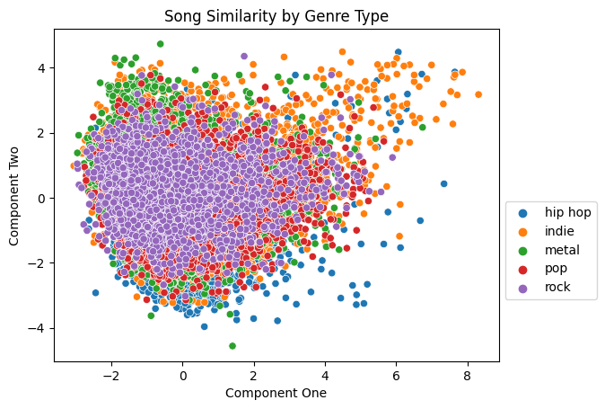

```python
# Graph One: Similarity of songs across multiple vectors
# creting a dataframe and merging the main genre type
X_pca = pd.DataFrame(X_pca, columns=["Component One", "Component Two"])
X_pca = pd.merge(subsety[['main_cat']], X_pca, left_index = True, right_index = True)
# graphing the similarity features and coloring by main genre type
sns.scatterplot(x="Component One", y="Component Two", hue="main_cat", data=X_pca)
plt.title("Song Similarity by Genre Type")
plt.legend(loc='best', bbox_to_anchor=(1, 0.5))
```

*It is difficult to linearably or clearly seperate data based on genre type, lets see if graphing the similairty regions around each genre makes these distinctions easier*

*Utilizing [Kernel Density Plots](https://seaborn.pydata.org/generated/seaborn.kdeplot.html) to display the similarity regions around each main category*

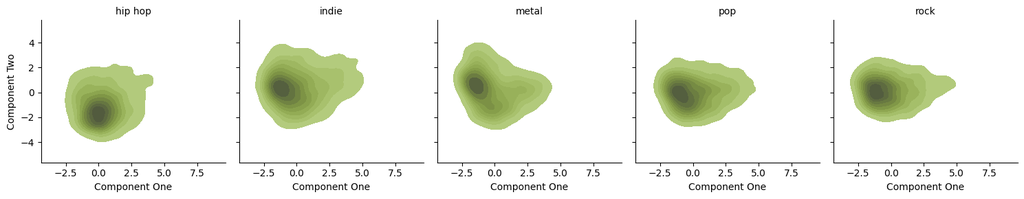

```python
# Graph Two - Showing Neighborhoods Shape by Genre Type
## utilizing facetgrid to plot all five categories from main_cat
neighborhoods = sns.FacetGrid(X_pca, col="main_cat", sharex=True, sharey=True)
## graphing the kernel density to see where each genre roughly lies
neighborhoods.map(sns.kdeplot, "Component One", "Component Two", color="#d5f979ff", fill=True)
# establishing the title as each graph as the name of the column
neighborhoods.set_titles(col_template="{col_name}")
```

*While some regions are shifted and more compressed than others, for the most part, there is significant overlap between song features genre to genre, lets see if we can get more variability when we graph by playlists*

*There are over 1300 playlist represented in the dataset, we will limit the playlists shown graphically to the top 8*

```python
## Graph Three:
## is there similarity within playlist? and differentiability across playlists
## limiting to songs that are a part of a playlist that is represented at least 100 times in the dataframe
value_counts = subset['Playlist'].value_counts()
subset = value_counts[value_counts > 95].index
subset = combo[combo['Playlist'].isin(subset)].reset_index()
```

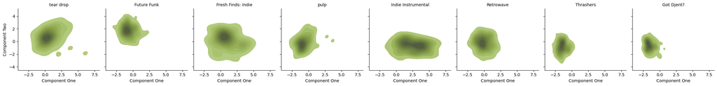

```python
## pulling the x variables based on numerical song features
subsetx = subset[['danceability', 'energy', 'key', 'loudness', 'mode', 'speechiness',
       'acousticness', 'instrumentalness', 'liveness', 'valence', 'tempo']]

# scaling the data
scaler = StandardScaler()
subsetx = scaler.fit_transform(subsetx)
## y is the playlist the songs belong to
subsety = subset[['Playlist']]

## compressing the data into two columns
pca = PCA(n_components=2)
X_pca = pca.fit_transform(subsetx)
# creting a dataframe and merging the main genre type
X_pca = pd.DataFrame(X_pca, columns=["Component One", "Component Two"])
X_pca = pd.merge(subsety[['Playlist']], X_pca, left_index = True, right_index = True)

## graphing the kernel density to see where each playlist roughly lies
neighborhoods = sns.FacetGrid(X_pca, col="Playlist", sharex=True, sharey=True)
neighborhoods.map(sns.kdeplot, "Component One", "Component Two", color="#d5f979ff", fill=True,warn_singular=False)
neighborhoods.set_titles(col_template="{col_name}")
```

*Since we have seen the most variability across songs from different playlists I have chosen to make this my final output variable. I will build a model that will assign songs to unique playlists*

## **MACHINE LEARNING MODEL**

### **STEP ONE - GENRE PROPAGATION**

```python
# OUR X VARIABLES WILL BE THE 11 QUANTITATIVE VARIABLES SHARED BETEWEEN THE TWO DATASETS
X = combo[['danceability','energy', 'key', 'loudness', 'mode', 'speechiness', 'acousticness','instrumentalness', 'liveness', 'valence', 'tempo']]
# OUR FIRST CLUSTERING MODEL WILL BE BASED ON THE MAIN CATEGORY ASSIGNED TO SONGS
Y = combo[['main_cat']]
```

```python
# INITIALIZING A KMEANS CLUSTERING MODEL THAT CLUSTERS ALL THE SONGS BASED ON QUANTITATIVE SIMILARITY
# I CHOSE 15 CLUSTERS TO ENSURE THAT ALL FIVE MAIN CATEGORIES WERE REPRESENTATED
kmeans = KMeans(n_clusters=15, n_init=10)
X_dist = kmeans.fit_transform(X)
# DISTANCE OF EACH TRACK FROM THE 15 CENTERS
X_dist
```

```
array([[31.15891194, 21.89261763, 85.64627615, ..., 19.03262616,
        41.36822771, 53.49055382],
       [29.76190728, 22.21242228, 84.0957667 , ..., 18.05660452,
        39.91911081, 52.0010951 ],
       [12.59721845, 51.99022558, 44.25780406, ..., 34.50300297,
         6.46374311, 13.41742872],
       ...,
       [ 5.44831397, 45.98845177, 52.22592018, ..., 29.05817349,
         8.8452366 , 20.29485137],
       [ 6.14958748, 48.27482269, 49.04708616, ..., 31.00539346,
         5.0120271 , 16.89190819],
       [ 3.61649487, 40.96733216, 55.99843587, ..., 23.85519134,
        12.0584064 , 23.99623567]])
```

```python
# WE ONLY WANT TO CREATE CENTER LABELS BASED ON THE SONG MOST CLOSE TO EACH CENTER W/ A NON NULL MAIN CAT
valid_rows = ~pd.isna(Y['main_cat'])
filtered_df = Y[valid_rows]
```

```python
# FILTERING THE LISTS OF SONGS TO ONLY BE THOSE WITH AN OUTCOME LABEL
X_dist_filtered = X_dist[valid_rows]
# SETTING THE CENTER LABEL TO BE THE SONG WITH MIN DISTANCE FROM THE CENTER
representative_label_idx = np.argmin(X_dist_filtered, axis=0)
representative_label_idx = Y[valid_rows].index[representative_label_idx]
representative_label_idx
```

```
Int64Index([16244,  3899, 14435,  6176, 19799,  3533,  5851, 21316, 15039,
            12440,  6570,  7132,  4112, 14786, 10343],
           dtype='int64')
```

```python
#QUANTITATIVE FEATURES RELATED TO THE CENTER SONGS
X_representative_labels = X.loc[representative_label_idx]
 # LABELS OF THE SONGS AT THE CENTER
y_representative_labels = np.array(Y.loc[representative_label_idx])
```

```python
# PROPOGATING GENRE ONTO EVERY SONG IN X BASED ON THE CLUSTER IT BELONGED TO
y_propagated = np.empty(len(X), dtype=object)
for i in range(15):
    y_propagated[kmeans.labels_==i] = y_representative_labels[i]
```

```python
# CREATING A NEW COLUMN THAT DISPLAYS THE PROPOGATED MAIN CATEGORY
combo['main_cat_prop'] = y_propagated
# REPLACING MAIN CATEGORY WITH PROPOGATED LABEL IF THE VALUE IS NULL
combo['main_cat'] = combo['main_cat'].fillna(combo['main_cat_prop'])
combo.head()
```

|  | primary_artist | name | Playlist | danceability | energy | key | loudness | mode | speechiness | acousticness | instrumentalness | liveness | valence | tempo | duration_ms | main_cat | subgenre1 | subgenre2 | subgenre3 | main_cat_prop |
| --- | --- | --- | --- | --- | --- | --- | --- | --- | --- | --- | --- | --- | --- | --- | --- | --- | --- | --- | --- | --- |
| 0 | 21 Savage | Spiral | No Cap | 0.814 | 0.659 | 2 | -4.475 | 1 | 0.0829 | 0.00155 | 0.025100 | 0.568 | 0.130 | 88.506 | 171527 | hip hop | atl hip hop | rap | trap | rock |
| 1 | VIC MENSA | SHELTER ft Wyclef Jean, ft Chance The Rapper | Mellow Bars | 0.664 | 0.660 | 0 | -5.284 | 1 | 0.2910 | 0.18100 | 0.000002 | 0.190 | 0.470 | 90.106 | 261467 | hip hop | chicago rap | conscious hip hop | hip hop | rock |
| 2 | Pooh Shiesty | Welcome To The Riches (feat. Lil Baby) | No Cap | 0.842 | 0.400 | 11 | -11.308 | 0 | 0.4860 | 0.04570 | 0.000000 | 0.172 | 0.205 | 130.018 | 192052 | hip hop | memphis hip hop | rap | southern hip hop | rock |
| 3 | Athletic Progression | Stepney Tale | Jazz Rap | 0.632 | 0.800 | 5 | -7.227 | 0 | 0.2340 | 0.54700 | 0.000000 | 0.147 | 0.496 | 92.757 | 209833 | hip hop | aarhus indie | danish modern jazz | jazz rap | rock |
| 4 | Ghetts | Fire and Brimstone | Grime Shutdown | 0.846 | 0.511 | 1 | -8.116 | 1 | 0.2630 | 0.03750 | 0.000005 | 0.147 | 0.346 | 136.964 | 190773 | hip hop | grime | uk alternative hip hop | uk hip hop | pop |

##### **GRAPHICAL REPRESENTATION OF CLUSTERING MODEL**

```python
# COMPRESSING THE DATA INTO TWO DIMENSIONS FOR SCATTER PLOT
pca = PCA(n_components=2)
X_pca = pca.fit_transform(X)
# THE LABELS ARE THE PROPAGATED MAIN CATEGORY
labels = combo.main_cat
# CREATING A DATA FRAME WHERE PCA1 IS THE FIRST COMPONENT AND PCA2 IS THE SECOND
# HUE WILL BE ACCORDING TO LABEL
visualization = pd.DataFrame({'PCA1': X_pca[:, 0], 'PCA2': X_pca[:, 1], 'PROP_GENRE': labels})
visualization.head()
```

|  | PCA1 | PCA2 | PROP_GENRE |
| --- | --- | --- | --- |
| 0 | -28.849928 | -8.808937 | hip hop |
| 1 | -27.299423 | -7.879013 | hip hop |
| 2 | 12.216420 | 0.219969 | hip hop |
| 3 | -24.759572 | -5.858289 | hip hop |
| 4 | 19.325073 | -2.427352 | hip hop |

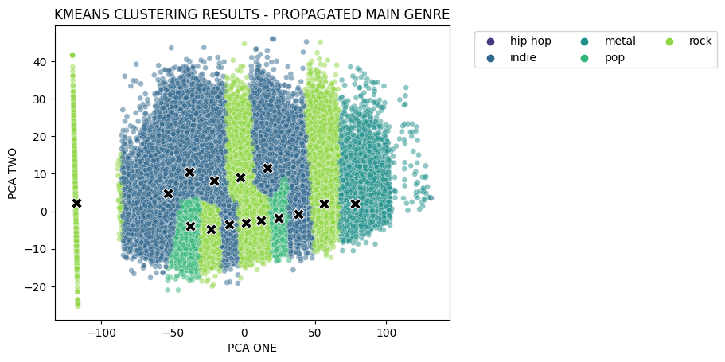

```python
# PLOTTING COMPONENTS BY PROPAGATED GENRE TYPE, SIZE AND TRANSPARENCY ADJUSTED FOR VISABILITY
sns.scatterplot(x='PCA1', y='PCA2', hue='PROP_GENRE', palette='viridis', data=visualization, s=25, alpha=0.50)
# ADDING X MARKERS AT THE CENTERS OF EACH CLUSTER
# APPLYING THE SAME PCA TRANSFORMATION TO THESE CENTER POINTS
centers_pca = pca.transform(kmeans.cluster_centers_)
sns.scatterplot(x=centers_pca[:, 0], y=centers_pca[:, 1], marker='X', s=100, color='black')
# ADDING TITLES AND LABELS
plt.title('KMEANS CLUSTERING RESULTS - PROPAGATED MAIN GENRE')
plt.xlabel('PCA ONE')
plt.ylabel('PCA TWO')
plt.legend(bbox_to_anchor=(1.05, 1), loc='upper left', ncol = 3)
plt.show()
```

### **STEP TWO - SUBGENRE PROPOGATION (THREE ITERATIONS)**

#### **SUBGENRE ONE**

```python
# OUR X VARIABLES WILL BE THE 11 QUANTITATIVE VARIABLES SHARED BETEWEEN THE TWO DATASETS
X = combo[['danceability','energy', 'key', 'loudness', 'mode', 'speechiness', 'acousticness','instrumentalness', 'liveness', 'valence', 'tempo']]
# OUR SECOND CLUSTERING MODEL WILL BE BASED ON THE SUBGENRE 1 ASSIGNED TO SONGS
Y = combo[['subgenre1']]
```

```python
k = 40
# INITIALIZING A KMEANS CLUSTERING MODEL THAT CLUSTERS ALL THE SONGS BASED ON QUANTITATIVE SIMILARITY
kmeans = KMeans(n_clusters=k, n_init=10)
X_dist = kmeans.fit_transform(X)
# DISTANCE OF EACH TRACK FROM THE 40 CENTERS
X_dist
```

```
array([[25.1083022 , 85.95949778, 11.05361464, ..., 73.21512041,
        33.996832  , 12.99629074],
       [23.50144056, 84.32654616, 13.1964748 , ..., 71.70612625,
        34.44770049, 13.05947392],
       [19.24057569, 44.30261329, 49.75088499, ..., 32.23701508,
        63.6748783 , 43.09684309],
       ...,
       [11.31588511, 53.21679765, 41.65724003, ..., 39.78492223,
        58.36012168, 36.24151623],
       [12.37381669, 49.98113267, 44.66237502, ..., 36.6074394 ,
        60.53586021, 38.67251906],
       [ 4.89636053, 56.15945321, 38.12222798, ..., 43.73468664,
        53.2510428 , 31.42289452]])
```

```python
# WE ONLY WANT TO CREATE CENTER LABELS BASED ON THE SONG MOST CLOSE TO EACH CENTER W/ A NON NULL SUBGENRE1
valid_rows = ~pd.isna(Y['subgenre1'])
filtered_df = Y[valid_rows]
```

```python
# FILTERING THE LISTS OF SONGS TO ONLY BE THOSE WITH AN OUTCOME LABEL
X_dist_filtered = X_dist[valid_rows]
# SETTING THE CENTER LABEL TO BE THE SONG WITH MIN DISTANCE FROM THE CENTER
representative_label_idx = np.argmin(X_dist_filtered, axis=0)
# INDEX OF SONGS AT THE CENTER WITH A LABEL
representative_label_idx = Y[valid_rows].index[representative_label_idx]
representative_label_idx
```

```
Int64Index([14778, 19573, 18963,   117,  8758, 14512,  6403, 18729, 15039,
            11078,  3781, 10435,  6873, 17176, 14817,  6021, 20395, 15504,
             3077,  2110,   899,  2897,  3458, 14856,  5259,  3899, 14638,
             6406, 18891,  6141, 21245, 20720, 13566, 16646,  2009, 11199,
              281,  8183,  6802,  3539],
           dtype='int64')
```

```python
#QUANTITATIVE FEATURES RELATED TO THE CENTER SONGS
X_representative_labels = X.loc[representative_label_idx]
# LABELS OF THE SONGS AT THE CENTER
y_representative_labels = np.array(Y.loc[representative_label_idx])
```

```python
# PROPOGATING SUBGENRE 1 ONTO EVERY SONG IN X BASED ON THE CLUSTER IT BELONGED TO
y_propagated = np.empty(len(X), dtype= object)
for i in range(k):
    y_propagated[kmeans.labels_==i] = y_representative_labels[i]
```

```python
# CREATING A NEW COLUMN FOR SUBGENRE PROPOGATION
combo['subgenre1_prop'] = y_propagated
# FILLING SONGS THAT ARE MISSING A SUBGENRE 1 WITH THE PROPOGATED LABEL
combo['subgenre1'] = combo['subgenre1'].fillna(combo['subgenre1_prop'])
combo.head()
```

|  | primary_artist | name | Playlist | danceability | energy | key | loudness | mode | speechiness | acousticness | ... | liveness | valence | tempo | duration_ms | main_cat | subgenre1 | subgenre2 | subgenre3 | main_cat_prop | subgenre1_prop |
| --- | --- | --- | --- | --- | --- | --- | --- | --- | --- | --- | --- | --- | --- | --- | --- | --- | --- | --- | --- | --- | --- |
| 0 | 21 Savage | Spiral | No Cap | 0.814 | 0.659 | 2 | -4.475 | 1 | 0.0829 | 0.00155 | ... | 0.568 | 0.130 | 88.506 | 171527 | hip hop | atl hip hop | rap | trap | rock | britpop |
| 1 | VIC MENSA | SHELTER ft Wyclef Jean, ft Chance The Rapper | Mellow Bars | 0.664 | 0.660 | 0 | -5.284 | 1 | 0.2910 | 0.18100 | ... | 0.190 | 0.470 | 90.106 | 261467 | hip hop | chicago rap | conscious hip hop | hip hop | rock | britpop |
| 2 | Pooh Shiesty | Welcome To The Riches (feat. Lil Baby) | No Cap | 0.842 | 0.400 | 11 | -11.308 | 0 | 0.4860 | 0.04570 | ... | 0.172 | 0.205 | 130.018 | 192052 | hip hop | memphis hip hop | rap | southern hip hop | rock | escape room |
| 3 | Athletic Progression | Stepney Tale | Jazz Rap | 0.632 | 0.800 | 5 | -7.227 | 0 | 0.2340 | 0.54700 | ... | 0.147 | 0.496 | 92.757 | 209833 | hip hop | aarhus indie | danish modern jazz | jazz rap | rock | electropop |
| 4 | Ghetts | Fire and Brimstone | Grime Shutdown | 0.846 | 0.511 | 1 | -8.116 | 1 | 0.2630 | 0.03750 | ... | 0.147 | 0.346 | 136.964 | 190773 | hip hop | grime | uk alternative hip hop | uk hip hop | pop | melodic hardcore |

5 rows × 21 columns

##### **GRAPHICAL REPRESENTATION OF CLUSTERING MODEL -- SUBGENRE ONE**

```python
# COMPRESSING THE DATA INTO TWO DIMENSIONS FOR SCATTER PLOT
pca = PCA(n_components=2)
X_pca = pca.fit_transform(X)
# THE LABELS ARE THE PROPAGATED SUBGENRE
labels = combo.subgenre1_prop
# CREATING A DATA FRAME WHERE PCA1 IS THE FIRST COMPONENT AND PCA2 IS THE SECOND
# HUE WILL BE ACCORDING TO LABEL
visualization = pd.DataFrame({'PCA1': X_pca[:, 0], 'PCA2': X_pca[:, 1], 'PROP_SUBGENRE': labels})
visualization.head()
```

|  | PCA1 | PCA2 | PROP_SUBGENRE |
| --- | --- | --- | --- |
| 0 | -28.849928 | -8.808937 | britpop |
| 1 | -27.299423 | -7.879013 | britpop |
| 2 | 12.216420 | 0.219969 | escape room |
| 3 | -24.759572 | -5.858289 | electropop |
| 4 | 19.325073 | -2.427352 | melodic hardcore |

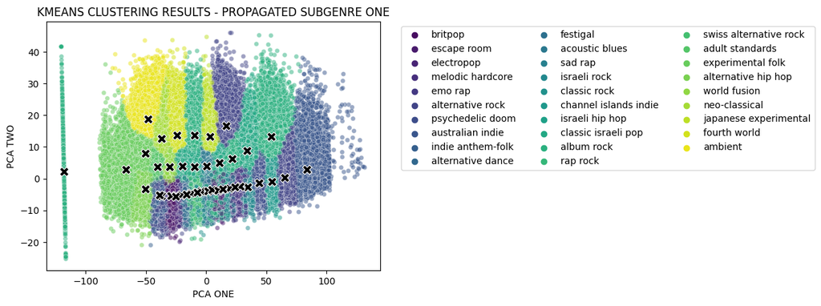

```python
# PLOTTING COMPONENTS BY PROPAGATED SUBGENRE -- TYPE, SIZE AND TRANSPARENCY ADJUSTED FOR VISABILITY
sns.scatterplot(x='PCA1', y='PCA2', hue='PROP_SUBGENRE', palette='viridis', data=visualization, s=25, alpha=0.50)
# ADDING X MARKERS AT THE CENTERS OF EACH CLUSTER
# APPLYING THE SAME PCA TRANSFORMATION TO THESE CENTER POINTS
centers_pca = pca.transform(kmeans.cluster_centers_)
sns.scatterplot(x=centers_pca[:, 0], y=centers_pca[:, 1], marker='X', s=100, color='black')
# ADDING TITLES AND LABELS
plt.title('KMEANS CLUSTERING RESULTS - PROPAGATED SUBGENRE ONE')
plt.xlabel('PCA ONE')
plt.ylabel('PCA TWO')
plt.legend(bbox_to_anchor=(1.05, 1), loc='upper left', ncol = 3)
plt.show()
```

#### **SUBGENRE TWO:**

```python
# OUR X VARIABLES WILL BE THE 11 QUANTITATIVE VARIABLES SHARED BETEWEEN THE TWO DATASETS
X = combo[['danceability','energy', 'key', 'loudness', 'mode', 'speechiness', 'acousticness','instrumentalness', 'liveness', 'valence', 'tempo']]
# OUR THIRD CLUSTERING MODEL WILL BE BASED ON THE SECOND SUBGENRE ASSIGNED TO SONGS
Y = combo[['subgenre2']]
```

```python
k = 40
# INITIALIZING A KMEANS CLUSTERING MODEL THAT CLUSTERS ALL THE SONGS BASED ON QUANTITATIVE SIMILARITY
kmeans = KMeans(n_clusters= k, n_init=10)
X_dist = kmeans.fit_transform(X)
X_dist
```

```
array([[ 51.00447442, 114.4736377 ,  23.78418377, ...,  33.12057127,
         88.70925856,   5.220893  ],
       [ 49.38043161, 112.91124966,  22.77184009, ...,  31.50895688,
         87.18758908,   3.91774277],
       [ 18.28638286,  73.026865  ,  35.36710579, ...,  12.94833504,
         47.65010338,  38.72239557],
       ...,
       [ 25.3957725 ,  81.00149986,  31.17561528, ...,   7.39156092,
         55.26540111,  30.33794077],
       [ 23.12421815,  77.89020025,  32.79023015, ...,   5.57426529,
         52.14446556,  32.6969158 ],
       [ 24.73019429,  84.87283327,  25.90828261, ...,   3.80498828,
         59.26497474,  25.47548837]])
```

```python
# WE ONLY WANT TO CREATE CENTER LABELS BASED ON THE SONG MOST CLOSE TO EACH CENTER W/ A NON NULL SUBGENRE 2
valid_rows = ~pd.isna(Y['subgenre2'])
filtered_df = Y[valid_rows]
```

```python
# FILTERING THE LISTS OF SONGS TO ONLY BE THOSE WITH AN OUTCOME LABEL
X_dist_filtered = X_dist[valid_rows]
# SETTING THE CENTER LABEL TO BE THE SONG WITH MIN DISTANCE FROM THE CENTER
representative_label_idx = np.argmin(X_dist_filtered, axis=0)
# INDEXES OF SONGS AT THE CENTER WITH A LABEL
representative_label_idx = Y[valid_rows].index[representative_label_idx]
representative_label_idx
```

```
Int64Index([ 6873,  2897,  5385,  2547,  9295,  3318, 21454, 14512,  6731,
             9441, 15039,   281,  4779,  3533,  2625, 11469,  8829, 19195,
             2609,  9802,  8229, 20720,   291, 18891,  2009,  8616, 20395,
             3521,  3604, 21905, 19573,   674,  6802, 17156, 17490, 16044,
             6750, 15641, 16511,     7],
           dtype='int64')
```

```python
#QUANTITATIVE FEATURES RELATED TO THE CENTER SONGS
X_representative_labels = X.loc[representative_label_idx]
# LABELS OF THE SONGS AT THE CENTER
y_representative_labels = np.array(Y.loc[representative_label_idx])
```

```python
# PROPOGATING GENRE ONTO EVERY SONG IN X BASED ON THE CLUSTER IT BELONGED TO
y_propagated = np.empty(len(X), dtype= object)
for i in range(k):
    y_propagated[kmeans.labels_==i] = y_representative_labels[i]
```

```python
# CREATING A SUBGENRE PROPAGATION LABEL IN COMBO AND FILLING SONGS THAT ARE MISSING A SUBGENRE 2
combo['subgenre2_prop'] = y_propagated
combo['subgenre2'] = combo['subgenre2'].fillna(combo['subgenre2_prop'])
combo.head()
```

|  | primary_artist | name | Playlist | danceability | energy | key | loudness | mode | speechiness | acousticness | ... | valence | tempo | duration_ms | main_cat | subgenre1 | subgenre2 | subgenre3 | main_cat_prop | subgenre1_prop | subgenre2_prop |
| --- | --- | --- | --- | --- | --- | --- | --- | --- | --- | --- | --- | --- | --- | --- | --- | --- | --- | --- | --- | --- | --- |
| 0 | 21 Savage | Spiral | No Cap | 0.814 | 0.659 | 2 | -4.475 | 1 | 0.0829 | 0.00155 | ... | 0.130 | 88.506 | 171527 | hip hop | atl hip hop | rap | trap | rock | britpop | detroit trap |
| 1 | VIC MENSA | SHELTER ft Wyclef Jean, ft Chance The Rapper | Mellow Bars | 0.664 | 0.660 | 0 | -5.284 | 1 | 0.2910 | 0.18100 | ... | 0.470 | 90.106 | 261467 | hip hop | chicago rap | conscious hip hop | hip hop | rock | britpop | detroit trap |
| 2 | Pooh Shiesty | Welcome To The Riches (feat. Lil Baby) | No Cap | 0.842 | 0.400 | 11 | -11.308 | 0 | 0.4860 | 0.04570 | ... | 0.205 | 130.018 | 192052 | hip hop | memphis hip hop | rap | southern hip hop | rock | escape room | uk house |
| 3 | Athletic Progression | Stepney Tale | Jazz Rap | 0.632 | 0.800 | 5 | -7.227 | 0 | 0.2340 | 0.54700 | ... | 0.496 | 92.757 | 209833 | hip hop | aarhus indie | danish modern jazz | jazz rap | rock | electropop | detroit trap |
| 4 | Ghetts | Fire and Brimstone | Grime Shutdown | 0.846 | 0.511 | 1 | -8.116 | 1 | 0.2630 | 0.03750 | ... | 0.346 | 136.964 | 190773 | hip hop | grime | uk alternative hip hop | uk hip hop | pop | melodic hardcore | progressive doom |

5 rows × 22 columns

##### **GRAPHICAL REPRESENTATION OF CLUSTERING MODEL -- SUBGENRE TWO**

```python
# COMPRESSING THE DATA INTO TWO DIMENSIONS FOR SCATTER PLOT
pca = PCA(n_components=2)
X_pca = pca.fit_transform(X)
# THE LABELS ARE THE PROPAGATED SUBGENRE
labels = combo.subgenre2_prop
# CREATING A DATA FRAME WHERE PCA1 IS THE FIRST COMPONENT AND PCA2 IS THE SECOND
# HUE WILL BE ACCORDING TO LABEL
visualization = pd.DataFrame({'PCA1': X_pca[:, 0], 'PCA2': X_pca[:, 1], 'PROP_SUBGENRE': labels})
visualization.head()
```

|  | PCA1 | PCA2 | PROP_SUBGENRE |
| --- | --- | --- | --- |
| 0 | -28.849928 | -8.808937 | detroit trap |
| 1 | -27.299423 | -7.879013 | detroit trap |
| 2 | 12.216420 | 0.219969 | uk house |
| 3 | -24.759572 | -5.858289 | detroit trap |
| 4 | 19.325073 | -2.427352 | progressive doom |

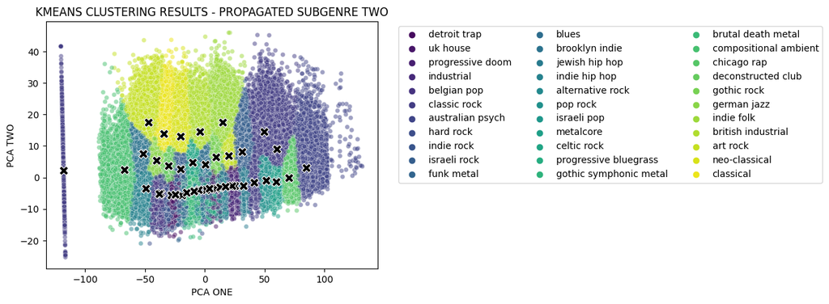

```python
# PLOTTING COMPONENTS BY PROPAGATED SUBGENRE -- TYPE, SIZE AND TRANSPARENCY ADJUSTED FOR VISABILITY
sns.scatterplot(x='PCA1', y='PCA2', hue='PROP_SUBGENRE', palette='viridis', data=visualization, s=25, alpha=0.50)
# ADDING X MARKERS AT THE CENTERS OF EACH CLUSTER
# APPLYING THE SAME PCA TRANSFORMATION TO THESE CENTER POINTS
centers_pca = pca.transform(kmeans.cluster_centers_)
sns.scatterplot(x=centers_pca[:, 0], y=centers_pca[:, 1], marker='X', s=100, color='black')
# ADDING TITLES AND LABELS
plt.title('KMEANS CLUSTERING RESULTS - PROPAGATED SUBGENRE TWO')
plt.xlabel('PCA ONE')
plt.ylabel('PCA TWO')
plt.legend(bbox_to_anchor=(1.05, 1), loc='upper left', ncol = 3)
plt.show()
```

#### **SUBGENRE THREE:**

```python
# OUR X VARIABLES WILL BE THE 11 QUANTITATIVE VARIABLES SHARED BETEWEEN THE TWO DATASETS
X = combo[['danceability','energy', 'key', 'loudness', 'mode', 'speechiness', 'acousticness','instrumentalness', 'liveness', 'valence', 'tempo']]
# OUR FOURTH CLUSTERING MODEL WILL BE BASED ON THE THIRD SUBGENRE ASSIGNED TO SONGS
Y = combo[['subgenre3']]
```

```python
k = 40
# INITIALIZING A KMEANS CLUSTERING MODEL THAT CLUSTERS ALL THE SONGS BASED ON QUANTITATIVE SIMILARITY
kmeans = KMeans(n_clusters= k, n_init=10)
X_dist = kmeans.fit_transform(X)
X_dist
```

```
array([[45.13715268,  7.92447058, 30.53948862, ..., 22.08749767,
        50.43472261, 20.92426365],
       [43.57367502,  8.88037147, 28.93093746, ..., 23.74953841,
        48.81881489, 19.61524431],
       [ 7.94765322, 38.20600656, 14.76507954, ..., 62.56799643,
        13.21453344, 26.74972408],
       ...,
       [14.83409063, 29.94279672,  7.97589674, ..., 54.65558718,
        18.43001467, 21.14214005],
       [11.7806233 , 32.9787755 ,  7.47522411, ..., 57.44587851,
        14.5326016 , 22.96490718],
       [15.93506956, 26.7270106 ,  1.81552604, ..., 50.43056519,
        20.89266012, 15.95220671]])
```

```python
# WE ONLY WANT TO CREATE CENTER LABELS BASED ON THE SONG MOST CLOSE TO EACH CENTER W/ A NON NULL SUBGENRE 3
valid_rows = ~pd.isna(Y['subgenre3'])
filtered_df = Y[valid_rows]
```

```python
# FILTERING THE LISTS OF SONGS TO ONLY BE THOSE WITH AN OUTCOME LABEL
X_dist_filtered = X_dist[valid_rows]
# SETTING THE CENTER LABEL TO BE THE SONG WITH MIN DISTANCE FROM THE CENTER
representative_label_idx = np.argmin(X_dist_filtered, axis=0)
representative_label_idx = Y[valid_rows].index[representative_label_idx]
representative_label_idx
```

```
Int64Index([ 2844, 13566, 11264,  2897,  2609, 17490,  6802,  3706,  2343,
             3318, 14101, 19641,  8758,  3533,  6873, 18991, 17343,  7417,
            11199,   291, 15039,  6021, 16646,  7260, 10970,  3521, 11469,
             8662,  3269,  3458,  4326, 12023, 18259, 15340, 19573,  2362,
             2559,   281,  8693, 16954],
           dtype='int64')
```

```python
#QUANTITATIVE FEATURES RELATED TO THE CENTER SONGS
X_representative_labels = X.loc[representative_label_idx]
 # LABELS OF THE SONGS AT THE CENTER
y_representative_labels = np.array(Y.loc[representative_label_idx])
```

```python
# PROPOGATING GENRE ONTO EVERY SONG IN X BASED ON THE CLUSTER IT BELONGED TO
y_propagated = np.empty(len(X), dtype=object)
for i in range(k):
    y_propagated[kmeans.labels_==i] = y_representative_labels[i]
```

```python
# ADDING SUBGENRE 3 PROPAGATIONS TO THE DATASET
combo['subgenre3_prop'] = y_propagated
combo['subgenre3'] = combo['subgenre3'].fillna(combo['subgenre3_prop'])
combo.head()
```

|  | primary_artist | name | Playlist | danceability | energy | key | loudness | mode | speechiness | acousticness | ... | tempo | duration_ms | main_cat | subgenre1 | subgenre2 | subgenre3 | main_cat_prop | subgenre1_prop | subgenre2_prop | subgenre3_prop |
| --- | --- | --- | --- | --- | --- | --- | --- | --- | --- | --- | --- | --- | --- | --- | --- | --- | --- | --- | --- | --- | --- |
| 0 | 21 Savage | Spiral | No Cap | 0.814 | 0.659 | 2 | -4.475 | 1 | 0.0829 | 0.00155 | ... | 88.506 | 171527 | hip hop | atl hip hop | rap | trap | rock | britpop | detroit trap | mod revival |
| 1 | VIC MENSA | SHELTER ft Wyclef Jean, ft Chance The Rapper | Mellow Bars | 0.664 | 0.660 | 0 | -5.284 | 1 | 0.2910 | 0.18100 | ... | 90.106 | 261467 | hip hop | chicago rap | conscious hip hop | hip hop | rock | britpop | detroit trap | mod revival |
| 2 | Pooh Shiesty | Welcome To The Riches (feat. Lil Baby) | No Cap | 0.842 | 0.400 | 11 | -11.308 | 0 | 0.4860 | 0.04570 | ... | 130.018 | 192052 | hip hop | memphis hip hop | rap | southern hip hop | rock | escape room | uk house | hard rock |
| 3 | Athletic Progression | Stepney Tale | Jazz Rap | 0.632 | 0.800 | 5 | -7.227 | 0 | 0.2340 | 0.54700 | ... | 92.757 | 209833 | hip hop | aarhus indie | danish modern jazz | jazz rap | rock | electropop | detroit trap | post-teen pop |
| 4 | Ghetts | Fire and Brimstone | Grime Shutdown | 0.846 | 0.511 | 1 | -8.116 | 1 | 0.2630 | 0.03750 | ... | 136.964 | 190773 | hip hop | grime | uk alternative hip hop | uk hip hop | pop | melodic hardcore | progressive doom | hurdy-gurdy |

5 rows × 23 columns

##### **GRAPHICAL REPRESENTATION OF CLUSTERING MODEL -- SUBGENRE THREE**

```python
# COMPRESSING THE DATA INTO TWO DIMENSIONS FOR SCATTER PLOT
pca = PCA(n_components=2)
X_pca = pca.fit_transform(X)
# THE LABELS ARE THE PROPAGATED SUBGENRE
labels = combo.subgenre3_prop
# CREATING A DATA FRAME WHERE PCA1 IS THE FIRST COMPONENT AND PCA2 IS THE SECOND
# HUE WILL BE ACCORDING TO LABEL
visualization = pd.DataFrame({'PCA1': X_pca[:, 0], 'PCA2': X_pca[:, 1], 'PROP_SUBGENRE': labels})
visualization.head()
```

|  | PCA1 | PCA2 | PROP_SUBGENRE |
| --- | --- | --- | --- |
| 0 | -28.849928 | -8.808937 | mod revival |
| 1 | -27.299423 | -7.879013 | mod revival |
| 2 | 12.216420 | 0.219969 | hard rock |
| 3 | -24.759572 | -5.858289 | post-teen pop |
| 4 | 19.325073 | -2.427352 | hurdy-gurdy |

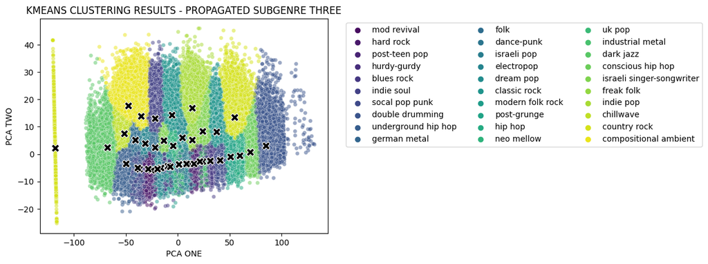

```python
# PLOTTING COMPONENTS BY PROPAGATED SUBGENRE -- TYPE, SIZE AND TRANSPARENCY ADJUSTED FOR VISABILITY
sns.scatterplot(x='PCA1', y='PCA2', hue='PROP_SUBGENRE', palette='viridis', data=visualization, s=25, alpha=0.50)
# ADDING X MARKERS AT THE CENTERS OF EACH CLUSTER
# APPLYING THE SAME PCA TRANSFORMATION TO THESE CENTER POINTS
centers_pca = pca.transform(kmeans.cluster_centers_)
sns.scatterplot(x=centers_pca[:, 0], y=centers_pca[:, 1], marker='X', s=100, color='black')
# ADDING TITLES AND LABELS
plt.title('KMEANS CLUSTERING RESULTS - PROPAGATED SUBGENRE THREE')
plt.xlabel('PCA ONE')
plt.ylabel('PCA TWO')
plt.legend(bbox_to_anchor=(1.05, 1), loc='upper left', ncol = 3)
plt.show()
```

### **STEP THREE - PLAYLIST PREDICTION AND EXPANSION**

```python
# NOW, I WANT TO CREATE A PROBABALISTIC MODEL THAT PREDICTS THE LIKLIHOOD A SONG BELONGS ON A PLAYLIST BASED ON ITS MAIN GENRE, AND 3 PROPAGATED SUBGENRES
X_names =combo[['primary_artist', 'name']]
X = combo[['main_cat', 'subgenre1_prop', 'subgenre2_prop', 'subgenre3_prop']]
Y = combo[['Playlist']]
```

```python
# CREATING DUMMIES FROM THE SUBGENRES
# FOR EVERY SUBGENRE REPRESENTED IN THE FRAME THERE WILL NOW BE A COLUMN THAT SAYS SUBGENRE1_PROP_...
X = pd.get_dummies(X)
```

```python
# INSTEAD OF HAVING THREE SUBGENRE COLUMNS FOR EACH SUBGENRE, I WANT TO COMBINE THEM ALL INTO ONE
## SELECTING COLUMNS THAT FOLLOW THE SUBGENRE#_PROP_ STRUCTURE USING REGULAR EXPRESSIONS
selected_columns = X.filter(regex=r'^subgenre[1-3]_prop_')
for column in selected_columns:
    # CREATING A STRING WITH WHATEVER OCCURS AFTER PROP_
    ## [2] SELECTS THE ENTIRE PHRASE AND NOT JUST PORTIONS
    prop_part = column.split("_")[2]
    # CREATING A NEW COLUMN WHERE IT IS TRUE IF THIS WAS ONE OF THE SUBGENRES FOR THE SONGS
    X[prop_part] = X[column].fillna('')
# DROPPING THE ORIGINAL COLUMNS THAT INCLUDED SUBGENRE_PROP_
X = X.drop(selected_columns, axis=1)
X.head()
```

|  | main_cat_hip hop | main_cat_indie | main_cat_metal | main_cat_pop | main_cat_rock | acoustic blues | adult standards | album rock | alternative dance | alternative hip hop | ... | industrial metal | israeli singer-songwriter | mod revival | modern folk rock | neo mellow | post-grunge | post-teen pop | socal pop punk | uk pop | underground hip hop |
| --- | --- | --- | --- | --- | --- | --- | --- | --- | --- | --- | --- | --- | --- | --- | --- | --- | --- | --- | --- | --- | --- |
| 0 | 1 | 0 | 0 | 0 | 0 | 0 | 0 | 0 | 0 | 0 | ... | 0 | 0 | 1 | 0 | 0 | 0 | 0 | 0 | 0 | 0 |
| 1 | 1 | 0 | 0 | 0 | 0 | 0 | 0 | 0 | 0 | 0 | ... | 0 | 0 | 1 | 0 | 0 | 0 | 0 | 0 | 0 | 0 |
| 2 | 1 | 0 | 0 | 0 | 0 | 0 | 0 | 0 | 0 | 0 | ... | 0 | 0 | 0 | 0 | 0 | 0 | 0 | 0 | 0 | 0 |
| 3 | 1 | 0 | 0 | 0 | 0 | 0 | 0 | 0 | 0 | 0 | ... | 0 | 0 | 0 | 0 | 0 | 0 | 1 | 0 | 0 | 0 |
| 4 | 1 | 0 | 0 | 0 | 0 | 0 | 0 | 0 | 0 | 0 | ... | 0 | 0 | 0 | 0 | 0 | 0 | 0 | 0 | 0 | 0 |

5 rows × 88 columns

```python
# OUR TRAINING SET FOR THE LAST MODEL WILL BE ALL SONGS THAT HAVE A PLAYLIST LABEL
valid_rows = ~pd.isna(Y['Playlist'])
Y_train = Y[valid_rows]
X_train = X[valid_rows]
```

```python
# FOR EASE OF COMPUTING AND INTERPRETABILITY, WE ARE ONLY GOING TO ADD SONGS TO THE TOP 50 PLAYLISTS REPRESENTED IN THE DATASET
value_counts = Y_train['Playlist'].value_counts()
# COUNT >82 GIVES US EXACTLY 50 PLAYLISTS
subset = value_counts[value_counts > 82].index
Y_train = Y_train[Y_train['Playlist'].isin(subset)]
X_train = X_train.loc[Y_train.index]
```

```python
# creating a dictionary that we can add to later
playlist_dictionary = {}
# for all of the playlists present in the limited training frame
for playlist in Y_train['Playlist'].unique():
    # the key is the playlist and the values are the songs belonging to that playlist
    current_playlist = {'Playlist': playlist, 'Songs': Y_train.index[Y_train['Playlist'] == playlist]}
    playlist_dictionary[playlist] = current_playlist
# displaying one of the playlist, song associations
playlist_dictionary['80s Soft Rock']
```

```
{'Playlist': '80s Soft Rock',
 'Songs': Int64Index([13944, 14074, 14160, 14213, 14232, 14324, 14385, 14386, 14476,
             14492, 14682, 14848, 14849, 14889, 15305, 15660, 15850, 16002,
             16009, 16084, 16217, 16228, 16378, 16391, 16403, 16498, 16519,
             16655, 16668, 16690, 16759, 16981, 17046, 17141, 17216, 17261,
             17288, 17428, 17452, 17626, 17648, 17691, 17885, 17923, 17972,
             18130, 18191, 18193, 18523, 18561, 18580, 18633, 18805, 18878,
             18885, 18887, 18933, 18941, 18998, 19082, 19135, 19369, 19538,
             19791, 20214, 20307, 20339, 20413, 20581, 20628, 20709, 20856,
             20931, 20994, 21120, 21126, 21263, 21479, 21761, 21846, 21907,
             21908, 21975, 22260, 22300, 22307, 22408],
            dtype='int64')}
```

```python
# training a logistic regression model to predict playlist names
model = LogisticRegression()
# train on all songs with a named playlist in the top 50 playlists represented
model.fit(X_train, Y_train)
```

```
LogisticRegression()
```

```python
# limiting the test / prediction set to be all songs that do not have a playlist
valid_rows = pd.isna(Y['Playlist'])
Y_test = Y[valid_rows]
X_test= X[valid_rows]
```

```python
# my computer crashes at all 1.1 million samples, so I am only predicting playlist names for 200k songs
X_test_sample = X_test.sample(n=200000)
Y_pred = model.predict(X_test_sample)
```

```python
# one benefit to the logistic regression model is that you can see the liklihood that each prediction belonged to each of the classification options
#grab the probabilities that each song belongs to one of the 50 playlists
probabilities = model.predict_proba(X_test_sample)
# create the dataframe that displays each song's probability of being in particular playlist
probabilities_df = pd.DataFrame(probabilities, columns=model.classes_)
probabilities_df
```

|  | 10s Pop Rock | 80s Soft Rock | Acoustic Hits | Altar | Beach Vibes | Black & Dark Metal | Black Metal Essentials | Deathcore | Deep Dive - 00s Metal | Deep Dive - 90s Metal | ... | Rocktronic | Shoegaze Classics | Soft Pop Hits | Stoner Rock | The Lot | Thrashers | Woodstock | pulp | tear drop | vaporwave |
| --- | --- | --- | --- | --- | --- | --- | --- | --- | --- | --- | --- | --- | --- | --- | --- | --- | --- | --- | --- | --- | --- |
| 0 | 0.051207 | 0.291030 | 0.001040 | 0.000359 | 0.058965 | 0.000620 | 0.000773 | 0.000690 | 0.000691 | 0.000661 | ... | 0.047921 | 0.001539 | 0.000971 | 0.000884 | 0.083552 | 0.000550 | 0.256982 | 0.000637 | 0.001113 | 0.000553 |
| 1 | 0.000305 | 0.000840 | 0.000466 | 0.031933 | 0.000192 | 0.000283 | 0.001892 | 0.001314 | 0.001687 | 0.000290 | ... | 0.000298 | 0.013194 | 0.001761 | 0.000625 | 0.001727 | 0.000164 | 0.001275 | 0.023309 | 0.001405 | 0.011339 |
| 2 | 0.000480 | 0.001626 | 0.260261 | 0.000192 | 0.003343 | 0.001564 | 0.001258 | 0.000309 | 0.000913 | 0.000806 | ... | 0.000410 | 0.000921 | 0.170773 | 0.001518 | 0.000263 | 0.000175 | 0.000402 | 0.000227 | 0.000589 | 0.000663 |
| 3 | 0.000757 | 0.002504 | 0.344866 | 0.000177 | 0.001791 | 0.000728 | 0.001138 | 0.000583 | 0.000350 | 0.000476 | ... | 0.001546 | 0.001555 | 0.217848 | 0.001397 | 0.000859 | 0.000711 | 0.000274 | 0.001853 | 0.001114 | 0.001636 |
| 4 | 0.192785 | 0.097623 | 0.001109 | 0.000157 | 0.138664 | 0.000247 | 0.000552 | 0.001090 | 0.000777 | 0.001634 | ... | 0.153260 | 0.000695 | 0.000895 | 0.000652 | 0.124255 | 0.002152 | 0.032819 | 0.000646 | 0.000246 | 0.002552 |
| ... | ... | ... | ... | ... | ... | ... | ... | ... | ... | ... | ... | ... | ... | ... | ... | ... | ... | ... | ... | ... | ... |
| 199995 | 0.000736 | 0.001617 | 0.000972 | 0.037113 | 0.000378 | 0.001127 | 0.000742 | 0.001233 | 0.001083 | 0.001602 | ... | 0.000740 | 0.045242 | 0.001524 | 0.000177 | 0.002212 | 0.001029 | 0.000877 | 0.055463 | 0.001409 | 0.057281 |
| 199996 | 0.000859 | 0.000391 | 0.001161 | 0.066156 | 0.001315 | 0.000262 | 0.001224 | 0.000920 | 0.001139 | 0.001005 | ... | 0.002023 | 0.071069 | 0.000923 | 0.001716 | 0.000432 | 0.000582 | 0.000657 | 0.113929 | 0.001548 | 0.084789 |
| 199997 | 0.001026 | 0.000172 | 0.000967 | 0.076222 | 0.002216 | 0.000709 | 0.001312 | 0.000563 | 0.001428 | 0.001807 | ... | 0.002900 | 0.097423 | 0.001830 | 0.001365 | 0.000422 | 0.000481 | 0.000772 | 0.066291 | 0.002480 | 0.077381 |
| 199998 | 0.000859 | 0.000391 | 0.001161 | 0.066156 | 0.001315 | 0.000262 | 0.001224 | 0.000920 | 0.001139 | 0.001005 | ... | 0.002023 | 0.071069 | 0.000923 | 0.001716 | 0.000432 | 0.000582 | 0.000657 | 0.113929 | 0.001548 | 0.084789 |
| 199999 | 0.000736 | 0.001617 | 0.000972 | 0.037113 | 0.000378 | 0.001127 | 0.000742 | 0.001233 | 0.001083 | 0.001602 | ... | 0.000740 | 0.045242 | 0.001524 | 0.000177 | 0.002212 | 0.001029 | 0.000877 | 0.055463 | 0.001409 | 0.057281 |

200000 rows × 50 columns

```python
# we will now create a dictionary that stores the five songs with the highest probability of being in that playlist
top_songs_dict = {}
# Loop through each column (playlist) in the DataFrame
for playlist in probabilities_df.columns:
    # Get the five top song based on largest probabilities
    top_song_indices = probabilities_df[playlist].nlargest(5).index[0:].to_list()
    # Store the top song indices in the dictionary
    top_songs_dict[playlist] = top_song_indices
```

```python
# for the top 50 playlists, recommend one song out of the top five predicted
for playlist in playlist_dictionary:
  # the index can be 0,1,2,3,4 and will select one of the top five songs
  random_index = random.randint(0, 4)
  print(f"If you like {playlist} then you may like {X_names.iloc[top_songs_dict[playlist][random_index]]['name']} by {X_names.iloc[top_songs_dict[playlist][random_index]]['primary_artist']} \n ")
```

```
If you like Mellow Bars then you may like Birds Are Chirping by D-Block Europe

If you like Jazz Rap then you may like The Jackson Song by Patti Smith

If you like tear drop then you may like Never Separate - A Song For Friends by Vickie Winans

If you like I Love My '90s Hip-Hop then you may like Before It All Ends by kent

If you like Lo-fi Indie then you may like Angel Witch by Angel Witch

If you like Ethereal then you may like Ride Again by The .357 STring Band

If you like vaporwave then you may like Jonella And Jack by Johnny Otis

If you like Future Funk then you may like Bionic Muscle by Truffel the Phunky Phaqir

If you like Fresh Finds: Indie then you may like Love's In Need Of Love Today by Stevie Wonder

If you like pulp then you may like Strange Fruit by Billie Holiday

If you like Indie Instrumental then you may like All or None by Pearl Jam

If you like Retrowave then you may like Enough by Surfing

If you like Shoegaze Classics then you may like The King Who Wouldn't Smile by The Handsome Family

If you like Fresh Finds: Experimental then you may like Antisocial by Patient Sixty-Seven

If you like Altar then you may like Solid (feat. Drake) by Young Stoner Life

If you like Noisy then you may like Enemies (feat. DaBaby) by Post Malone

If you like Modern Psychedelia then you may like colorblind (kina remix) by Mokita

If you like Northern Spirits then you may like 5 Below by Evie Ladin Band

If you like Thrashers then you may like כל החברים שלך by Anna Zak

If you like Metal Covers then you may like Body (Remix) [feat. ArrDee, E1 (3x3), ZT (3x3), Bugzy Malone, Buni, Fivio Foreign & Darkoo] by Tion Wayne

```

[output cut: 44 more lines]

```
If you like 10s Pop Rock then you may like Bad Boy (with Young Thug) by Juice WRLD

If you like Woodstock then you may like Alone (feat. Lil Durk) by 42 Dugg

If you like Deep Dive: 80s Rock then you may like זן נדיר by Korin Allal

If you like Prog Rock Monsters then you may like Twister by Stephen Vitiello

If you like 80s Soft Rock then you may like Maggie by Tanglefoot

If you like Rocktronic then you may like Scared by Kembe X

If you like Fresh Finds: Rock then you may like QUESO by AG Club

If you like Beach Vibes then you may like True Indeed by Busta Rhymes
```

## **CONCLUSIONS & FINAL REMARKS**

> RESULTS:
> - I was able to build a model that can recommend songs based on a playlist that a listener is already familiar with.
> - Similarity to songs in a playlist was built by iterating a set of 1.2M unlabeled songs through four semi-supervised KMEANS models. First, I assigned main genres using propagated labelling and then I followed the same logic to propagate a series of subgenres. With these four input columns, I build a probabalistic recommendation engine what took the top five most likely songs to be added to a playlist and displayed one song a user may like.

> LIMITATIONS:
> - I was only able to apply the logistic regression model to 200K songs, rather than the entirity of the 1.2M songs. Partially, this was due to computing power.
> - I also had to limit the number of subgenres that I propagated to each song, this was due to timing constraints as each KMEANS model took roughly 10 minutes to run
> - Lastly, I would have preffered to have assigned songs to all 1300 playlists represents but for ingestiability, I limited it to the top 50 playlists represented in the dataframe.
> - Since we are using unlabeled data, unable to track accuracy

> FURTHER APPLICATIONS:
> - Tying recommendations to consumer profiles
> - Expanding the number of playlists that are options to be added to
> - Increasing computing power to utilize all 1.2M songs in assigning recommendations to playlists
> - Integrating with an interactive platform like StreamLit so I can take the input of the user when giving recommendations.

```python
# Converting my CoLab to html so that I can upload this file to Github
!jupyter nbconvert --to html /content/drive/MyDrive/spotify_finaltutorial.ipynb
```

```
[NbConvertApp] Converting notebook /content/drive/MyDrive/spotify_finaltutorial.ipynb to html
[NbConvertApp] Writing 3089218 bytes to /content/drive/MyDrive/spotify_finaltutorial.html
```